# Лабораторная работа 7. Метод k-того ближайшего соседа

Natalia Korskova

2016-05-02

### Вариант 8. Оливковые масла

Считываем данные, смотрим на структуру:

```r
olive <- read.table("olive.txt", header = TRUE, sep = c(","))
str(olive)
```

```
## 'data.frame':    572 obs. of  11 variables:
##  $ name       : Factor w/ 572 levels "100.South-Apulia",..: 111 222 333 444 528 539 550 561 572 11 ...
##  $ region     : int  1 1 1 1 1 1 1 1 1 1 ...
##  $ area       : int  1 1 1 1 1 1 1 1 1 1 ...
##  $ palmitic   : int  1075 1088 911 966 1051 911 922 1100 1082 1037 ...
##  $ palmitoleic: int  75 73 54 57 67 49 66 61 60 55 ...
##  $ stearic    : int  226 224 246 240 259 268 264 235 239 213 ...
##  $ oleic      : int  7823 7709 8113 7952 7771 7924 7990 7728 7745 7944 ...
##  $ linoleic   : int  672 781 549 619 672 678 618 734 709 633 ...
##  $ linolenic  : int  36 31 31 50 50 51 49 39 46 26 ...
##  $ arachidic  : int  60 61 63 78 80 70 56 64 83 52 ...
##  $ eicosenoic : int  29 29 29 35 46 44 29 35 33 30 ...
```

С чтением данных произошла проблема: помимо разделителя запятой присутствует номер наблюдения, отделённый точкой от остальной части строки. Номер наблюдения не является переменной, заявленной в заголовке – сдвига по переменным нет. В переменной name нужно избавиться от номера и точки, сделаем это при помощи регулярных выражений:

```r
olive$name <- gsub('[0-9]+[.]', '', olive$name)
str(olive)
```

```
## 'data.frame':    572 obs. of  11 variables:
##  $ name       : chr  "North-Apulia" "North-Apulia" "North-Apulia" "North-Apulia" ...
##  $ region     : int  1 1 1 1 1 1 1 1 1 1 ...
##  $ area       : int  1 1 1 1 1 1 1 1 1 1 ...
##  $ palmitic   : int  1075 1088 911 966 1051 911 922 1100 1082 1037 ...
##  $ palmitoleic: int  75 73 54 57 67 49 66 61 60 55 ...
##  $ stearic    : int  226 224 246 240 259 268 264 235 239 213 ...
##  $ oleic      : int  7823 7709 8113 7952 7771 7924 7990 7728 7745 7944 ...
##  $ linoleic   : int  672 781 549 619 672 678 618 734 709 633 ...
##  $ linolenic  : int  36 31 31 50 50 51 49 39 46 26 ...
##  $ arachidic  : int  60 61 63 78 80 70 56 64 83 52 ...
##  $ eicosenoic : int  29 29 29 35 46 44 29 35 33 30 ...
```

Теперь со структурой данных всё в порядке. Краткие описательные статистики:

```r
summary(olive)
```

```
##      name               region           area        palmitic
##  Length:572         Min.   :1.000   Min.   :1.0   Min.   : 610
##  Class :character   1st Qu.:1.000   1st Qu.:3.0   1st Qu.:1095
##  Mode  :character   Median :1.000   Median :3.0   Median :1201
##                     Mean   :1.699   Mean   :4.6   Mean   :1232
##                     3rd Qu.:3.000   3rd Qu.:7.0   3rd Qu.:1360
##                     Max.   :3.000   Max.   :9.0   Max.   :1753
##   palmitoleic        stearic          oleic         linoleic
##  Min.   : 15.00   Min.   :152.0   Min.   :6300   Min.   : 448.0
##  1st Qu.: 87.75   1st Qu.:205.0   1st Qu.:7000   1st Qu.: 770.8
##  Median :110.00   Median :223.0   Median :7302   Median :1030.0
##  Mean   :126.09   Mean   :228.9   Mean   :7312   Mean   : 980.5
##  3rd Qu.:169.25   3rd Qu.:249.0   3rd Qu.:7680   3rd Qu.:1180.8
##  Max.   :280.00   Max.   :375.0   Max.   :8410   Max.   :1470.0
##    linolenic       arachidic       eicosenoic
##  Min.   : 0.00   Min.   :  0.0   Min.   : 1.00
##  1st Qu.:26.00   1st Qu.: 50.0   1st Qu.: 2.00
##  Median :33.00   Median : 61.0   Median :17.00
##  Mean   :31.89   Mean   : 58.1   Mean   :16.28
##  3rd Qu.:40.25   3rd Qu.: 70.0   3rd Qu.:28.00
##  Max.   :74.00   Max.   :105.0   Max.   :58.00
```

Пропущенных данных нет. Программа-минимум состоит в классификации оливковых масел для трёх регионов (переменная region) на основании жирных кислот (столбцы с 4 по 11).

Разобьём выборку на обучающее и тестовое множество в пропорции 2:1, убрав столбцы, отвечающие за область:

```r
set.seed(3141)
test_num <- sample(1:nrow(olive), 191, replace = FALSE)
olive_train <- olive[-test_num, 4:11]
olive_test <- olive[test_num, 4:11]
```

Код класса – переменная region:

```r
cl <- olive[-test_num, 2]
```

Попробуем работу метода k-ближайших соседей для k = 3:

```r
library(class)
res_01 <- knn(olive_train, olive_test, cl, k = 3)
```

Проверяем результат работы на тестовом множестве:

```r
table(res_01, olive[test_num, 2])
```

```
##
## res_01   1   2   3
##      1 104   0   1
##      2   1  36   1
##      3   1   0  47
```

Посмотрим, как производится суммирование (по столбцам или строкам) и посчитаем число ошибок классификатора:

```r
table(olive[test_num, 2])
```

```
##
##   1   2   3
## 106  36  49
```

```r
sum(res_01 != olive[test_num, 2])
```

```
## [1] 4
```

Суммирование производится по столбцам. Всего 4 ошибки. Проверим число ошибок для разного количества соседей:

```r
errors <- rep(0, 15)

for (i in 1:15){
    tmp <- knn(olive_train, olive_test, cl, k = i)
    errors[i] <- sum(tmp != olive[test_num, 2])
}
errors
```

```
##  [1]  2  6  4  5  4  3  3  3  3  3  5  7  6  8 10
```

Для 1 или 3 соседей результат неплохой, для 6-10 одинаковое число ошибок, а чем больше значения после – тем хуже. Хорошее число соседей 1, 3, либо 6. Лучше не брать большое число соседей (6-10), т.к. при другом разбиении на обучающее и тестовое множество большое число соседей может больше ошибок.

Перейдём к программе-максимум – выделить дополнительную область в новый регион. Посмотрим на карту, предложенную в описании данных:

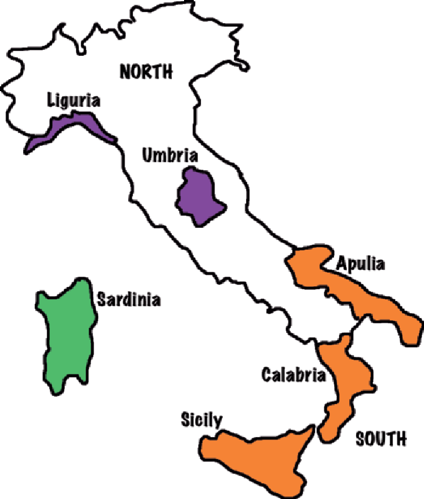

Возникает желание выделить область Умбрии отдельно по географическим соображениям – остальные регионы находятся более скученно:

```r
olive_1 <- olive
olive_1$region[olive_1$name == "Umbria"] <- 4
cl_1 <- olive_1[-test_num, 2]
```

```r
res_02 <- knn(olive_train, olive_test, cl_1, k = 1)
table(res_02, olive_1[test_num, 2])
```

```
##
## res_02   1   2   3   4
##      1 105   0   1   0
##      2   0  36   0   0
##      3   1   0  33   0
##      4   0   0   1  14
```

```r
sum(res_02 != olive_1[test_num, 2])
```

```
## [1] 3
```

Неплохой результат по ошибкам. Количество ошибок для разного числа соседей:

```r
errors_1 <- rep(0, 15)

for (i in 1:15){
    tmp <- knn(olive_train, olive_test, cl_1, k = i)
    errors_1[i] <- sum(tmp != olive_1[test_num, 2])
}
errors_1
```

```
##  [1]  3  6  6  7  7  7  5  6  5  6  7  8  7 12 12
```

Тоже неплохо, хотя для трёх регионов было лучше при таком разбиении данных. Зато теперь все области в регионах близки друг к другу.

Можно рассмотреть другой вариант отделения региона. Посмотрим на пропорциональное соотношение наблюдений:

```r
table(as.factor(olive[, 2]))
```

```
##
##   1   2   3
## 323  98 151
```

В первом регионе гораздо больше наблюдений, чем во втором и третьем. Посмотрим, сколько приходится на какую область:

```r
tmp <- olive[, 1:2]
tmp <- tmp[tmp$region == 1, ]
table(tmp)
```

```
##               region
## name             1
##   Calabria      56
##   North-Apulia  25
##   Sicily        36
##   South-Apulia 206
```

Логично не разделять Северную и Южную Апулию в разные регионы, выделим всю Апулию в новый регион. Это немного улучшит пропорции:

```r
olive_2 <- olive
olive_2$region[olive_2$name == "North-Apulia"] <- 4
olive_2$region[olive_2$name == "South-Apulia"] <- 4
table(as.factor(olive_2[, 2]))
```

```
##
##   1   2   3   4
##  92  98 151 231
```

Выделяем класс:

```r
cl_2 <- olive_2[-test_num, 2]
```

```r
res_03 <- knn(olive_train, olive_test, cl_2, k = 1)
table(res_03, olive_2[test_num, 2])
```

```
##
## res_03  1  2  3  4
##      1 19  0  0  2
##      2  0 36  0  0
##      3  0  0 48  1
##      4  5  0  1 79
```

```r
sum(res_03 != olive_2[test_num, 2])
```

```
## [1] 9
```

Ошибок много. Разное число соседей:

```r
errors_2 <- rep(0, 15)

for (i in 1:15){
    tmp <- knn(olive_train, olive_test, cl_2, k = i)
    errors_2[i] <- sum(tmp != olive_2[test_num, 2])
}
errors_2
```

```
##  [1]  9 14 15 14 14 15 12 10  9 15 14 15 18 17 19
```

Выделение Апулии в отдельный регион ухудшило ситуацию. Это согласуется со здравым смыслом – Апулия находится рядом со своими соседями по региону и тоже на побережье – климатические условия скорее всего похожи. Умбрия же находится в других климатических условиях, что сказывается на составе оливок и содержании кислот. Климатическая карта:

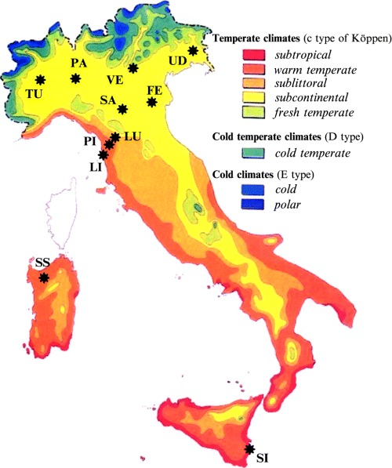

Область Умбрии имеет и другой климат по сравнению с областью Лигурии (с которой была в одном регионе), и находится в центре страны, в то время как как Лигурия на побережье.